# Interpretabilidad

Rubén Cobarro

Javier Serrat

El objetivo de SHAP es explicar la predicción de una instancia x calculando la contribución de cada característica a la predicción. El método de explicación SHAP calcula los valores de Shapley a partir de la teoría de los juegos de coalición.

Carga de datos

```python
df_car = pd.read_csv("/Users/javiserrat_/Desktop/NCDB_1999_to_2014 copia.csv")
```

```python
import shap
import pickle
import pandas as pd
import matplotlib.pyplot as plt
shap.initjs()
```

Importación de librerías

```python
import xgboost as xgb
from sklearn.model_selection import GridSearchCV
from sklearn.metrics import accuracy_score

from sklearn.metrics import confusion_matrix
import seaborn as sns


from sklearn.metrics import roc_auc_score
from sklearn.metrics import roc_curve
import matplotlib.pyplot as plt
from sklearn.metrics import roc_auc_score, roc_curve, plot_roc_curve
from sklearn import metrics
from sklearn.metrics import classification_report
from sklearn.ensemble import RandomForestRegressor, RandomForestClassifier
```

Importación de los ficheros del notebook

```python
ytest = pd.read_parquet('../new/ytest.parquet')
y_train_sampled = pd.read_parquet('../new/y_train_sampled.parquet')
xtest = pd.read_parquet('../new/X_test_pca.parquet')
x_train_sampled = pd.read_parquet('../new/X_train_pca.parquet')
```

```python
file = open('RandomForest.sav', 'rb')
pca_selected = pickle.load(file)
```

```python
model = pca_selected.best_estimator_
```

```python
shap_values = shap.TreeExplainer(model).shap_values(xtest)
```

SHAP feauture importance

```python
xtest.iloc[0,:]
```

```
PCA_0   -0.496011
PCA_1    0.443168
PCA_2    0.351952
PCA_3   -0.860589
PCA_4    0.079297
PCA_5   -0.395278
PCA_6   -1.047443
PCA_7    0.117230
PCA_8   -0.821935
PCA_9    0.506187
Name: 0, dtype: float64
```

La siguiente figura muestra la importancia de la característica SHAP para el bosque aleatorio entrenado anteriormente para predecir si habrá una muerte en un accidente de tráfico en Canadá.

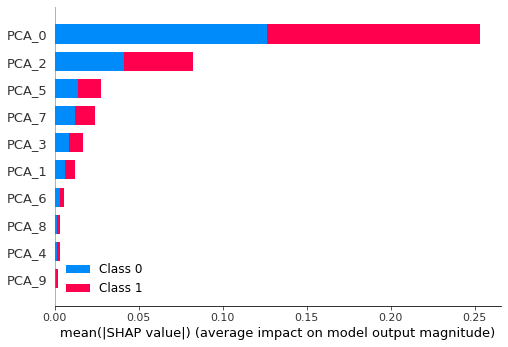

```python
shap.summary_plot(shap_values, xtest)
```

Mediante este grafico podemos observar que hay una clara tendencia del uso del componente PCA_0 superior al resto que muestra la determinación de la media de si habrá fallecimientos o no en un accidente de tráfico.

El siguiente gráfico combina la importancia de las características con los efectos de las mismas. Se ven los primeros indicios de la relación entre el valor de una característica y el impacto en la predicción, combina la importancia de las características con los efectos de las mismas. La posición en el eje y está determinada por la característica y en el eje x por el valor de Shap. El color representa el valor de la característica de menor a mayor. Los puntos que se superponen se desplazan en la dirección del eje Y, de modo que se obtiene una idea de la distribución de los valores de Shapley por característica. Las características se ordenan según su importancia.

SHAP summary plot

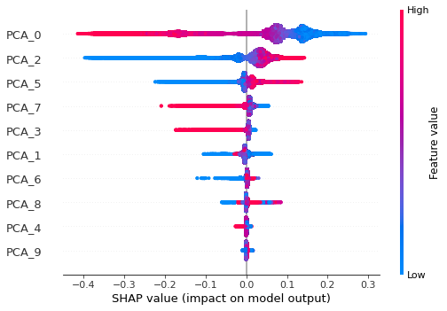

```python
shap.summary_plot(shap_values[0], features= xtest, max_display=10)
```